# Train, Test Split

Train test split is a model validation procedure that allows you to simulate how a model would perform on new/unseen data.

## Why do we split our data

To avoid overfitting. Overfitting is a modeling error when a function is too closely aligned to a limited set of data points. As a result, the model is useful in reference only to its initial data set, and not to any other data sets.

When our model is overfitted (like the image below), it is likely to perform worse on new data.

[figure not shown]

## The process

Once we have loaded our data, there are four steps:

1. Arrange the data into Features and Targets
2. Split the data into a training dataset and a testing dataset
3. Train the model using the training dataset. This is **X_train** and **y_train** in the image.
4. Test the model on the testing set (**X_test** and **y_test** in the image) and evaluate the performance.

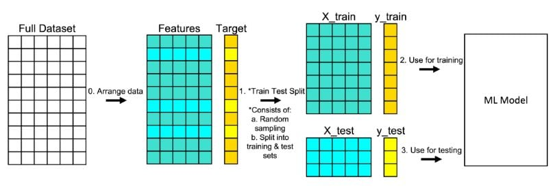

### Links

Statology has some great [python guides](https://www.statology.org/python-guides/). There is one specifcally on [How to Create a Train and Test Set from a Pandas DataFrame](https://www.statology.org/pandas-train-test/)

[Understanding Train Test Split](https://builtin.com/data-science/train-test-split)

# Terminology

- **Training dataset** - The sample of data used to fit the model.
- **Test dataset** - The sample of data used to provide an unbiased evaluation of a final model fit on the training dataset.
- **Validation dataset** - The sample of data used to provide an unbiased evaluation of a model fit on the training dataset while tuning model hyperparameters. The evaluation becomes more biased as skill on the validation dataset is incorporated into the model configuration.

**Note:** In this session we are only focusing on training and testing datasets.

# Load the Full dataset

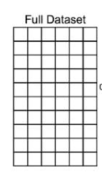

```python
# Load the required libraries
import pandas as pd

# For splitting our data into train and test datasets
from sklearn.model_selection import train_test_split

# classification metrics
from sklearn.metrics import accuracy_score, precision_score, recall_score, f1_score, confusion_matrix, ConfusionMatrixDisplay

# Regression metrics
from sklearn.metrics import mean_squared_error, mean_absolute_error
```

```python
# read the data
# Note: all data is stored in the data folder
golf_data = pd.read_csv('data\play_golf_dataset.csv')
display(golf_data)
```

|  | Day | Outlook | Temperature | Humidity | Wind | PlayGolf |
| --- | --- | --- | --- | --- | --- | --- |
| 0 | 1 | Sunny | Hot | High | Weak | No |
| 1 | 2 | Sunny | Hot | High | Strong | No |
| 2 | 3 | Overcast | Hot | High | Weak | Yes |
| 3 | 4 | Rain | Cool | Normal | Weak | Yes |
| 4 | 5 | Sunny | Mild | Normal | Weak | Yes |
| 5 | 6 | Rain | Mild | High | Strong | No |
| 6 | 7 | Overcast | Hot | Normal | Weak | Yes |
| 7 | 8 | Rain | Hot | Normal | Strong | ?????? |

```python
# Remove the non labelled observation as we can't use this to train or test

# Copy the last row into it's own dataset
unlabeled_data =  golf_data[-1:]

# Drop the last row from the golf_data
golf_data.drop(golf_data.tail(1).index,inplace=True) # drop last n rows

display(unlabeled_data)
display(golf_data)
```

|  | Day | Outlook | Temperature | Humidity | Wind | PlayGolf |
| --- | --- | --- | --- | --- | --- | --- |
| 7 | 8 | Rain | Hot | Normal | Strong | ?????? |

|  | Day | Outlook | Temperature | Humidity | Wind | PlayGolf |
| --- | --- | --- | --- | --- | --- | --- |
| 0 | 1 | Sunny | Hot | High | Weak | No |
| 1 | 2 | Sunny | Hot | High | Strong | No |
| 2 | 3 | Overcast | Hot | High | Weak | Yes |
| 3 | 4 | Rain | Cool | Normal | Weak | Yes |
| 4 | 5 | Sunny | Mild | Normal | Weak | Yes |
| 5 | 6 | Rain | Mild | High | Strong | No |
| 6 | 7 | Overcast | Hot | Normal | Weak | Yes |

# Arrange into Features and Target

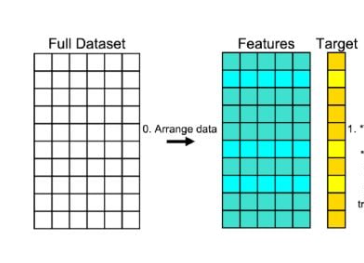

```python
# Define Features (indepdendent) and Target (Dependent) columns
# Note we are not using the Day column in our features
xcols = ['Outlook', 'Temperature', 'Humidity', 'Wind'] # These are the features
ycols = ['PlayGolf'] # This is the Target we want to predict

golf_features = golf_data[xcols] # Dataset with Features
golf_target = golf_data[ycols] # Dataset with Target column

display(golf_features) # Display features dataset
display(golf_target) # Display Target dataset
```

|  | Outlook | Temperature | Humidity | Wind |
| --- | --- | --- | --- | --- |
| 0 | Sunny | Hot | High | Weak |
| 1 | Sunny | Hot | High | Strong |
| 2 | Overcast | Hot | High | Weak |
| 3 | Rain | Cool | Normal | Weak |
| 4 | Sunny | Mild | Normal | Weak |
| 5 | Rain | Mild | High | Strong |
| 6 | Overcast | Hot | Normal | Weak |

|  | PlayGolf |
| --- | --- |
| 0 | No |
| 1 | No |
| 2 | Yes |
| 3 | Yes |
| 4 | Yes |
| 5 | No |
| 6 | Yes |

# Split the data into Train and Test

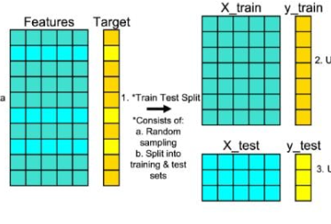

Now we will split our data into a training dataset and a testing dataset. Our training dataset will be 70% of our data, whiile our testing dataset will be 30%.

```python
# Call the train_test_split function to split our Features and Target datasets
X_train, X_test, y_train, y_test = train_test_split(golf_features, golf_target, test_size=0.3, random_state = 1)
```

```python
# This code is just to display the dataframes side by side to mirror the diagram
# to make it easier for those reading this to undrstand what has happened to the data
# You don't need to learn this for the course
from IPython.display import display_html

df1_style = X_train.style.set_table_attributes("style='display:inline; margin-right:20px;'").set_caption("Training Features")
df2_style = y_train.style.set_table_attributes("style='display:inline'").set_caption("Training Target")

display_html(df1_style._repr_html_() + df2_style._repr_html_(), raw=True)

df3_style = X_test.style.set_table_attributes("style='display:inline; margin-right:20px;'").set_caption("Test Features")
df4_style = y_test.style.set_table_attributes("style='display:inline'").set_caption("Test Target")

display_html(df3_style._repr_html_() + df4_style._repr_html_(), raw=True)
```

Training Features

|  | Outlook | Temperature | Humidity | Wind |
| --- | --- | --- | --- | --- |
| 0 | Sunny | Hot | High | Weak |
| 4 | Sunny | Mild | Normal | Weak |
| 3 | Rain | Cool | Normal | Weak |
| 5 | Rain | Mild | High | Strong |

Training Target

|  | PlayGolf |
| --- | --- |
| 0 | No |
| 4 | Yes |
| 3 | Yes |
| 5 | No |

Test Features

|  | Outlook | Temperature | Humidity | Wind |
| --- | --- | --- | --- | --- |
| 6 | Overcast | Hot | Normal | Weak |
| 2 | Overcast | Hot | High | Weak |
| 1 | Sunny | Hot | High | Strong |

Test Target

|  | PlayGolf |
| --- | --- |
| 6 | Yes |
| 2 | Yes |
| 1 | No |

Our data is now split ready to be used in our model

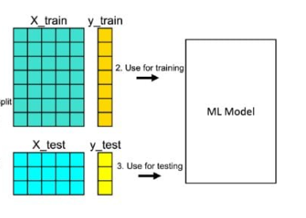

## The Train Test Split Function - Optional

The [train_test_split function](https://scikit-learn.org/stable/modules/generated/sklearn.model_selection.train_test_split.html) is provided by the model_selection subpackage available under the sklearn package. The function receives as input the following parameters:

- arrays — the datasets to be split;
- test_size — the size of the test set. It could be either a float or an integer number. If it is a float, it should be a number between 0.0 and 1.0 and represents the proportion of the dataset to include in the test set. If it is an integer, it is the total number of samples to include in the test set. If the test_size is not set, the value is set automatically to the complement of the train size;
- train_size — the size of the train set. Its behavior is complementary to the test_size variable;
- random_state — before applying to split, the dataset is shuffled. The random_state variable is an integer that initializes the seed used for shuffling. It is used to make the experiment reproducible;
- shuffle — it specifies whether to shuffle data before splitting or not. The default value is True;
- stratify — if not None, it specifies an array of frequencies for class labels. This permits the splitting phase the preserve the frequency of class labels as specified.

# Python Implementation of the Metrics

## Classification Evaluation Metrics

This website gives a good explanation of the classification evaluation metrics.[Confusion Matrix, Accuracy, Precision, Recall, F1 Score - How to evaluate the performance of a machine learning model?](https://medium.com/analytics-vidhya/confusion-matrix-accuracy-precision-recall-f1-score-ade299cf63cd)

You can find out more about the [Scikit Learn model evaluation functions](https://scikit-learn.org/stable/modules/model_evaluation.html) on their website.

```python
# read the data
eval_class = pd.read_csv('data\evaluate_classification_metric_data.csv')
print(eval_class)
```

```
    y_actual  y_predicted
0          0            1
1          1            0
2          1            0
3          1            0
4          1            1
5          0            0
6          0            1
7          0            0
8          1            1
9          0            1
10         1            0
11         1            0
12         1            0
13         0            1
```

[output cut: 16 more lines]

```python
#calculate metrics
acc = accuracy_score(eval_class["y_actual"], eval_class["y_predicted"]) # Accuracy Score
prec = precision_score(eval_class["y_actual"], eval_class["y_predicted"]) # Precision Score
rec = recall_score(eval_class["y_actual"], eval_class["y_predicted"]) # Recall Score
f1 = f1_score(eval_class["y_actual"], eval_class["y_predicted"]) # F1 score
cm = confusion_matrix(eval_class["y_actual"], eval_class["y_predicted"]) # Confusion Matrix

# Create the confusion matrix display
display_matrix = ConfusionMatrixDisplay(cm)
```

```
Accuracy is 0.533
Precision is 0.533
Recall is 0.533
F1 is 0.533
```

```
<sklearn.metrics._plot.confusion_matrix.ConfusionMatrixDisplay at 0x173e261bc10>
```

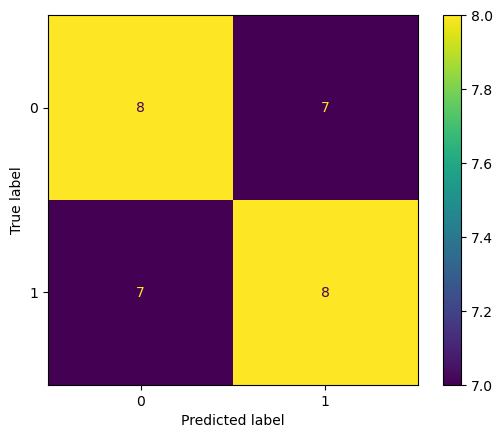

```python
# print metrics
print(f'Accuracy is {acc:.3f}')
print(f'Precision is {prec:.3f}')
print(f'Recall is {rec:.3f}')
print(f'F1 is {f1:.3f}')

#display confusion matrix
display_matrix.plot()
```

## Regression Evaluation Metrics

This website gives a good explanation of the regression evaluation metrics. [MAE, MSE, RMSE, Coefficient of Determination, Adjusted R Squared — Which Metric is Better](https://medium.com/analytics-vidhya/mae-mse-rmse-coefficient-of-determination-adjusted-r-squared-which-metric-is-better-cd0326a5697e)

```python
# read the data
eval_reg = pd.read_csv('data\evaluate_regression_metric_data.csv')
#print(eval_reg)
```

```python
#calculate regression metrics
mae = mean_absolute_error(eval_reg["y_actual"], eval_reg["y_predicted"]) # Mean Absolute Error
mse = mean_squared_error(eval_reg["y_actual"], eval_reg["y_predicted"]) # Mean Squared Error
# To get the RMSE we call the  mean_squared_error function but pass it squared = False
rmse = mean_squared_error(eval_reg["y_actual"], eval_reg["y_predicted"], squared = False) # Root Mean Squared Error
```

```python
print(f'MAE is {mae:.3f}')
print(f'MSE is {mse:.3f}')
print(f'RMSE is {rmse:.3f}')
```

```
MAE is 1.528
MSE is 4.676
RMSE is 2.162
```

## Pandas refresher

Check out the [Pandas Cheat Sheet](https://pandas.pydata.org/Pandas_Cheat_Sheet.pdf) for more help.

```python
# rows
# get all rows up to 4
display(golf_data[:5])

# get rows 2, 3 and 4
display(golf_data[2:5])

# get all rows except for the last two
display(golf_data[:-2])

# get all rows from the fifth last onwards
display(golf_data[-5:])

# columns
# get colums 2 onward for all rows
golf_data.iloc[:, 2:]

# get colums 1, 2 and 5 for all rows
golf_data.iloc[:, [1, 2, 5]]

# Rows and columns
# get colums 1, 2 and 5 for all rows 2 and 3
golf_data.iloc[2:4, [1, 2, 5]]
```

|  | Day | Outlook | Temperature | Humidity | Wind | PlayGolf |
| --- | --- | --- | --- | --- | --- | --- |
| 0 | 1 | Sunny | Hot | High | Weak | No |
| 1 | 2 | Sunny | Hot | High | Strong | No |
| 2 | 3 | Overcast | Hot | High | Weak | Yes |
| 3 | 4 | Rain | Cool | Normal | Weak | Yes |
| 4 | 5 | Sunny | Mild | Normal | Weak | Yes |

|  | Day | Outlook | Temperature | Humidity | Wind | PlayGolf |
| --- | --- | --- | --- | --- | --- | --- |
| 2 | 3 | Overcast | Hot | High | Weak | Yes |
| 3 | 4 | Rain | Cool | Normal | Weak | Yes |
| 4 | 5 | Sunny | Mild | Normal | Weak | Yes |

|  | Day | Outlook | Temperature | Humidity | Wind | PlayGolf |
| --- | --- | --- | --- | --- | --- | --- |
| 0 | 1 | Sunny | Hot | High | Weak | No |
| 1 | 2 | Sunny | Hot | High | Strong | No |
| 2 | 3 | Overcast | Hot | High | Weak | Yes |
| 3 | 4 | Rain | Cool | Normal | Weak | Yes |
| 4 | 5 | Sunny | Mild | Normal | Weak | Yes |

|  | Day | Outlook | Temperature | Humidity | Wind | PlayGolf |
| --- | --- | --- | --- | --- | --- | --- |
| 2 | 3 | Overcast | Hot | High | Weak | Yes |
| 3 | 4 | Rain | Cool | Normal | Weak | Yes |
| 4 | 5 | Sunny | Mild | Normal | Weak | Yes |
| 5 | 6 | Rain | Mild | High | Strong | No |
| 6 | 7 | Overcast | Hot | Normal | Weak | Yes |

|  | Outlook | Temperature | PlayGolf |
| --- | --- | --- | --- |
| 2 | Overcast | Hot | Yes |
| 3 | Rain | Cool | Yes |